# ASA PROJET

# VISUALISATION DES DONNEES SANS NAs

On visualise de nouveaux les distributions des variables explicatives, cette fois-ci avec les NAs imputés.

#### — Visualisation des distribution des X

**Facteurs**

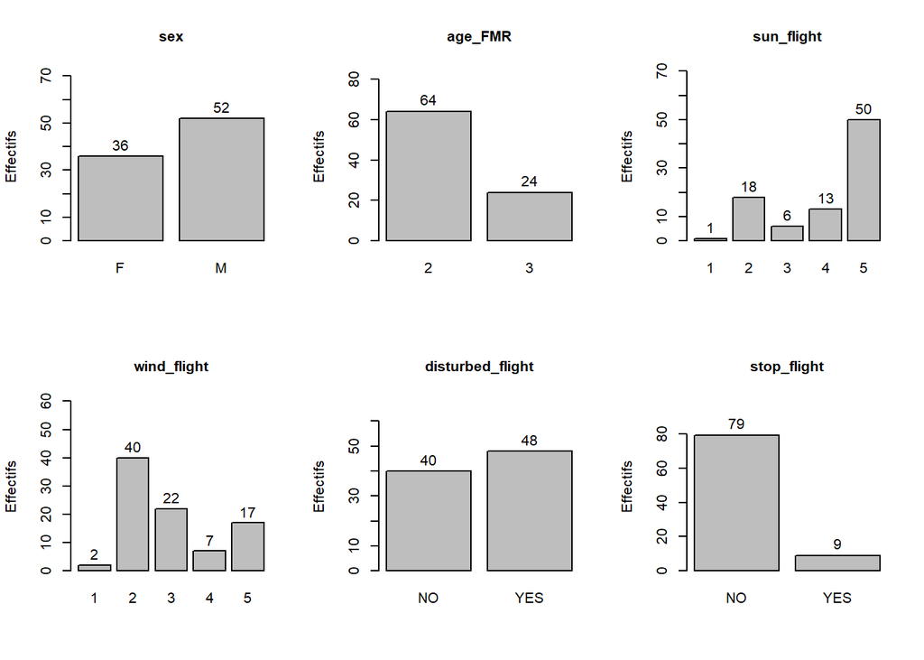

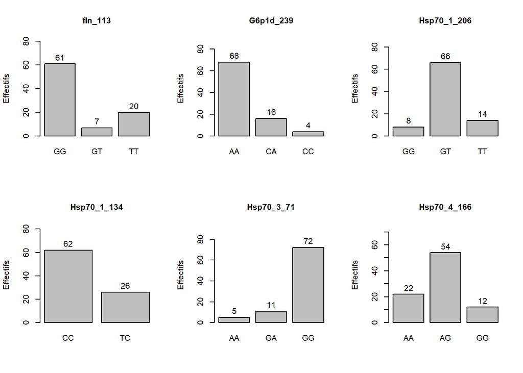

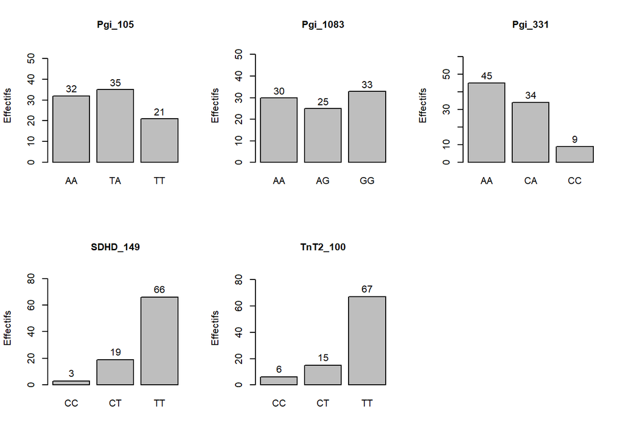

Comme vu originalement, es variables **sun_flight** et **wind_flight** ont une modalité (“1”) avec respectivement, 1 et 2 réplicats. Ces modalités sont inutilisables pour estimer des paramètres. On créé donc une autre modalité : “<2”.

```r
# Reformatage
# --- Sun_flight
data$sun_flight <- ifelse(
    test = data$sun_flight == 1 | data$sun_flight == 2,
    yes = "<2",
    no = data$sun_flight
  )

# --- Wind_flight
data$wind_flight <- ifelse(
    test = data$wind_flight == 1 | data$wind_flight == 2,
    yes = "<2",
    no = data$wind_flight
  )


# Conversion en facteur
data$sun_flight  <- as.factor(data$sun_flight)
data$wind_flight <- as.factor(data$wind_flight)

# On modifie aussi data_factor
data_factor$sun_flight <- data$sun_flight
data_factor$wind_flight <- data$wind_flight
```

Revisualisation

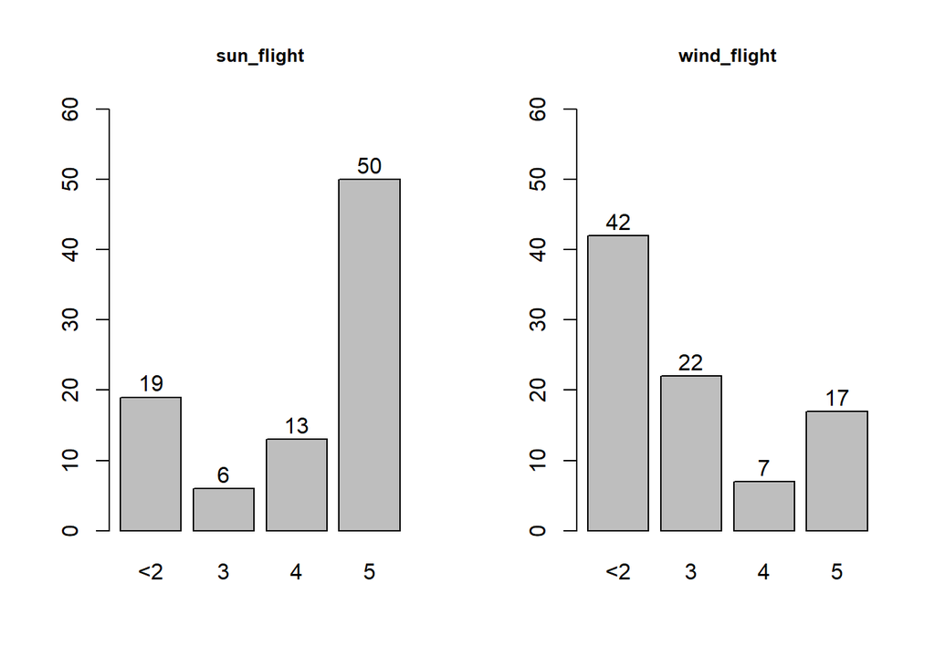

**Covariables**  
On visualise la distribution des variables quantitatives.

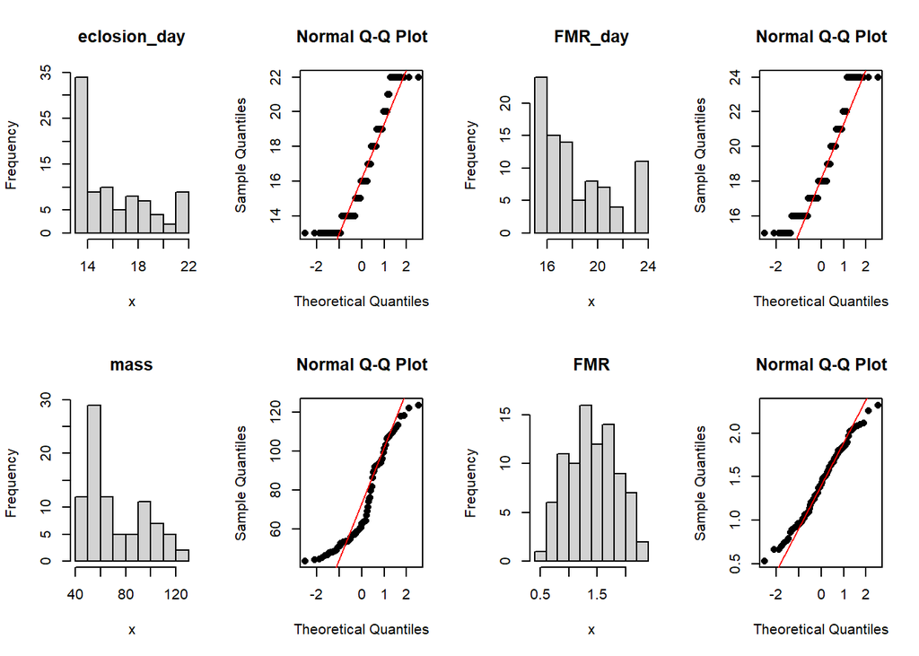

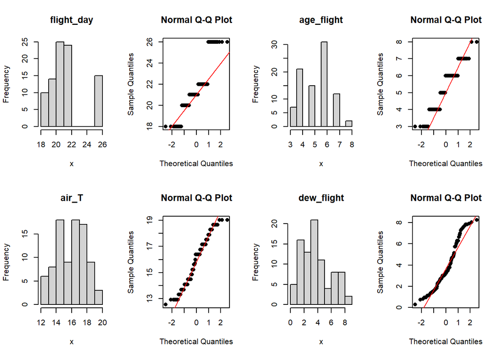

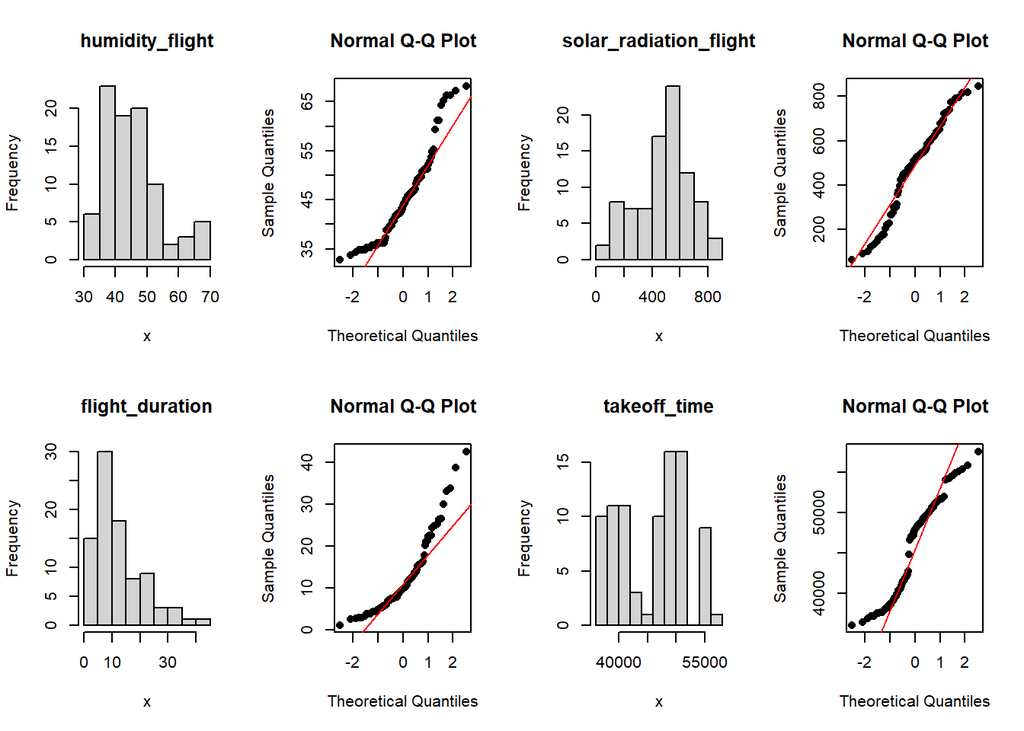

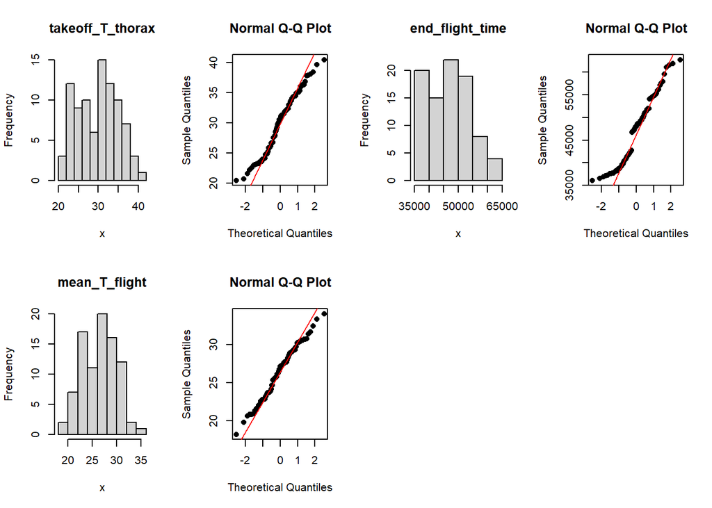

On transorme les variables suivantes avec le logaritme pour ‘normaliser’ la distribution :

- humidity_flight
- flight_duration

#### — Visualisation des distribution mean_T_flight ~ X

**Facteurs** On visualise la distribution de la variable réponse **mean_T_flight** en fonction des variables catégorielles.

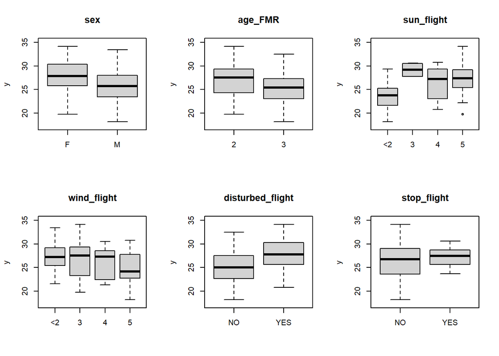

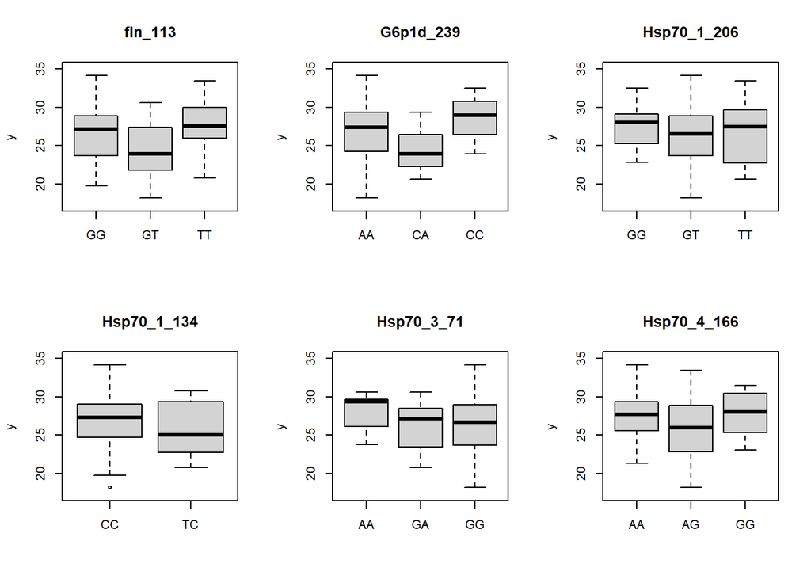

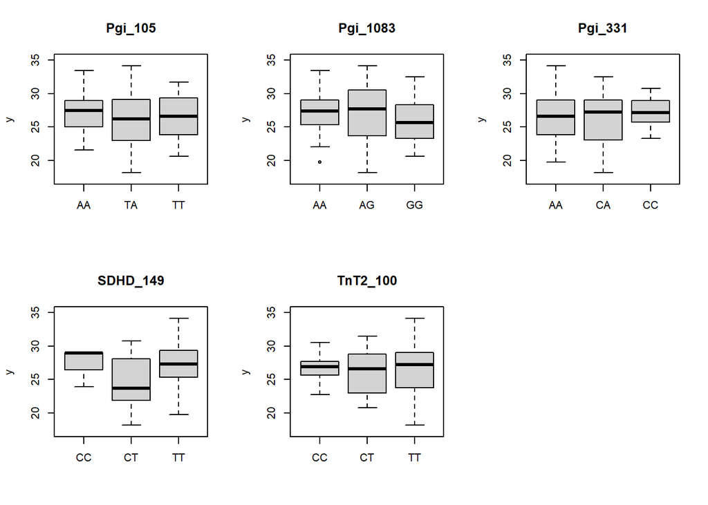

En considérant les barres d’erreurs, on n’observe pas de tendances notables entre les variables prédictives catégorielles et la variable réponse. Ce, même avec les nouvelles variables génétiques.

**Covariables**

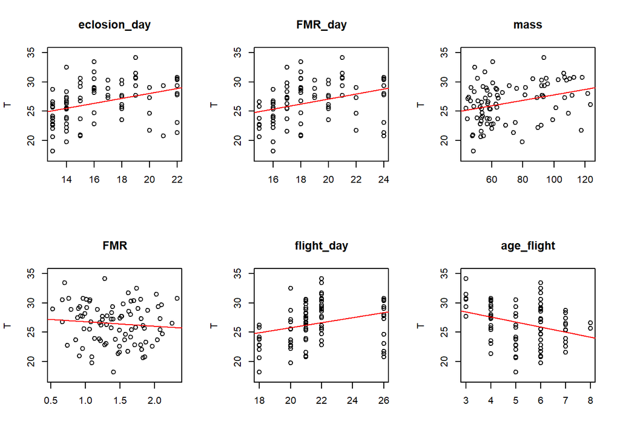

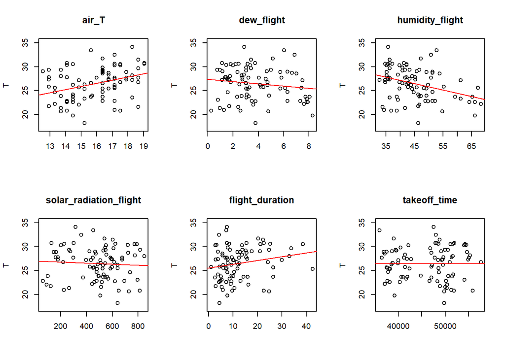

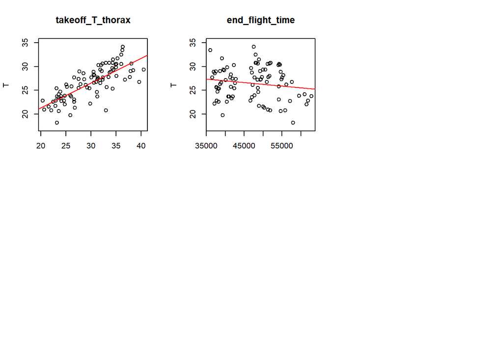

On observe toujours une relation linéaire positive entre **mean_T_flight** et les variables : eclosion_day, FMR_day, mass, air_T, flight_duration et takeoff_T_thorax. A l’inverse, on observe une relation linéaire négative entre **y** et age_flight, dew_flight, humidity_flight. Aucune relation entre **y** et les variables FMR, solar_radiation_flight, takeoff_time et end_flight_time.

# Intéractions entre y ~ facteurs / co-variables

### A) Gène * environnement

#### — Température de l’air et SNP331 (ref : bibliographie)

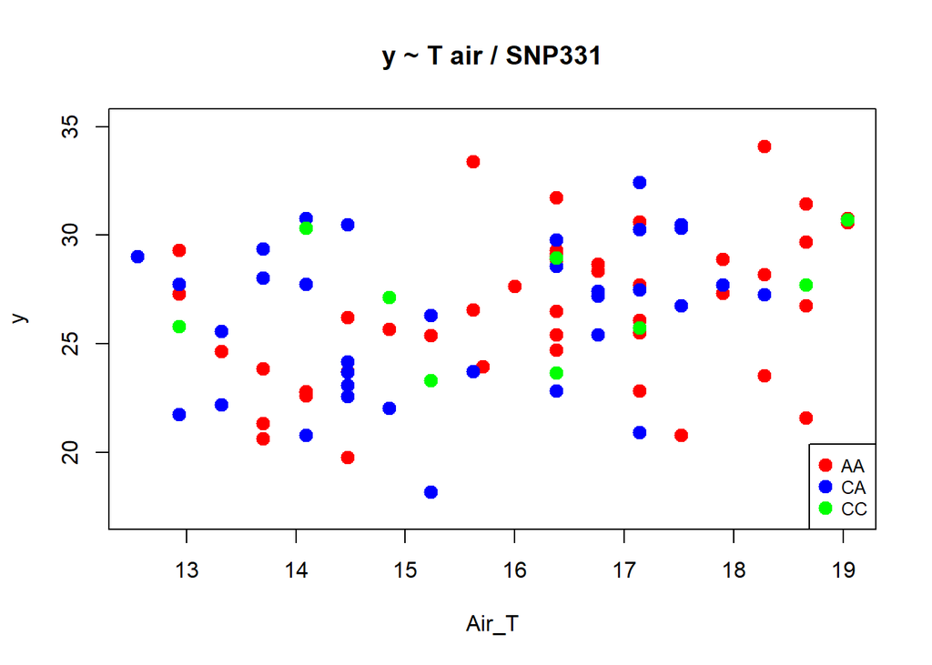

On n’observe pas de pattern clair d’interaction entre la température de l’air et le SNP331 sur la température du vol (tous les groupes [couleurs] de points se chevauchent).

### B) Sexe * variables physiologiques et comportementales

#### — y ~ Masse*sexe

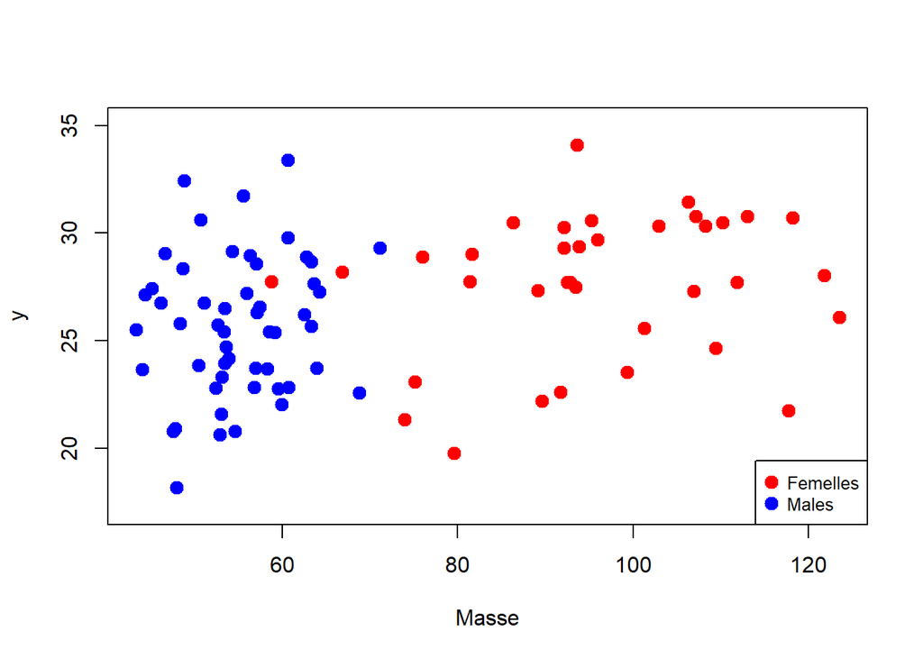

Les femelles sont nettement plus lourdes que les mâles ! Pas d’intéraction sexe x masse sur la température moyenne du corps pendant le vol.

#### — y ~ sexe*FMR

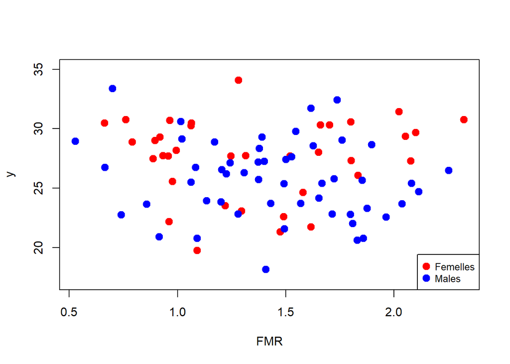

Pas d’interaction visible sexe*FMR sur la température.

#### — y ~ sexe*flight_duration

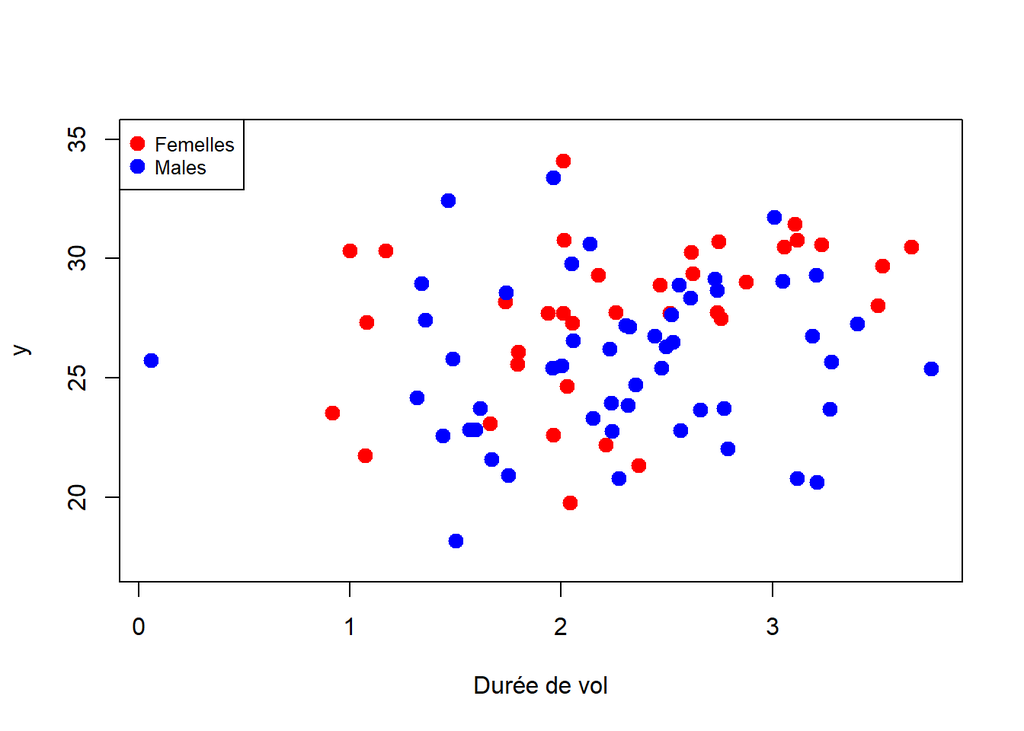

Pas d’interaction visible sexe*durée du vol sur la température.

#### — y ~ sexe*température au décollage

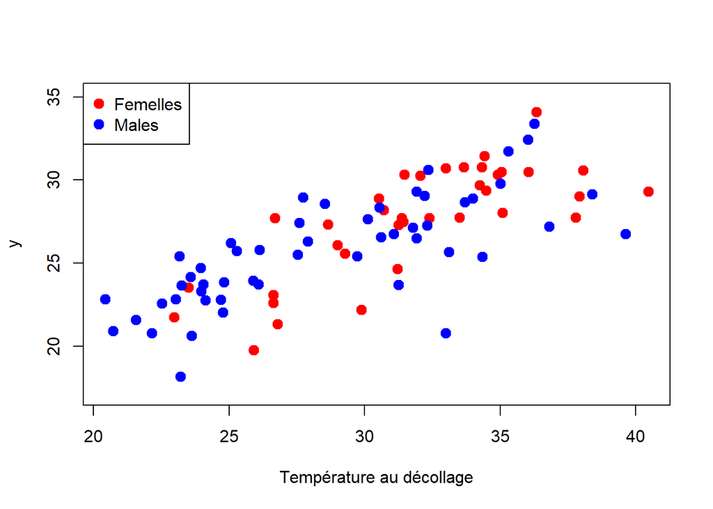

Pas d’interaction sexe*température au décollage sur la température pendant le vol.

#### — y ~ sexe*SNP331

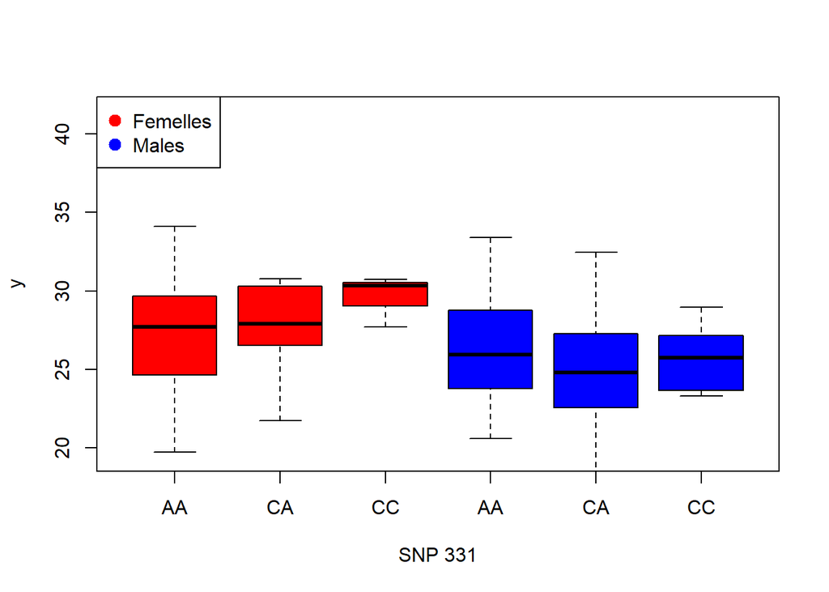

#### — y ~ sexe*SNP105

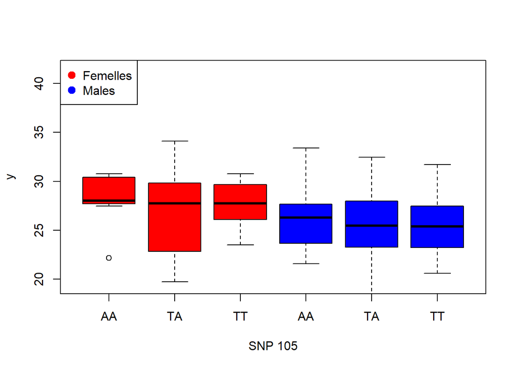

#### — y ~ sexe*SNP1083

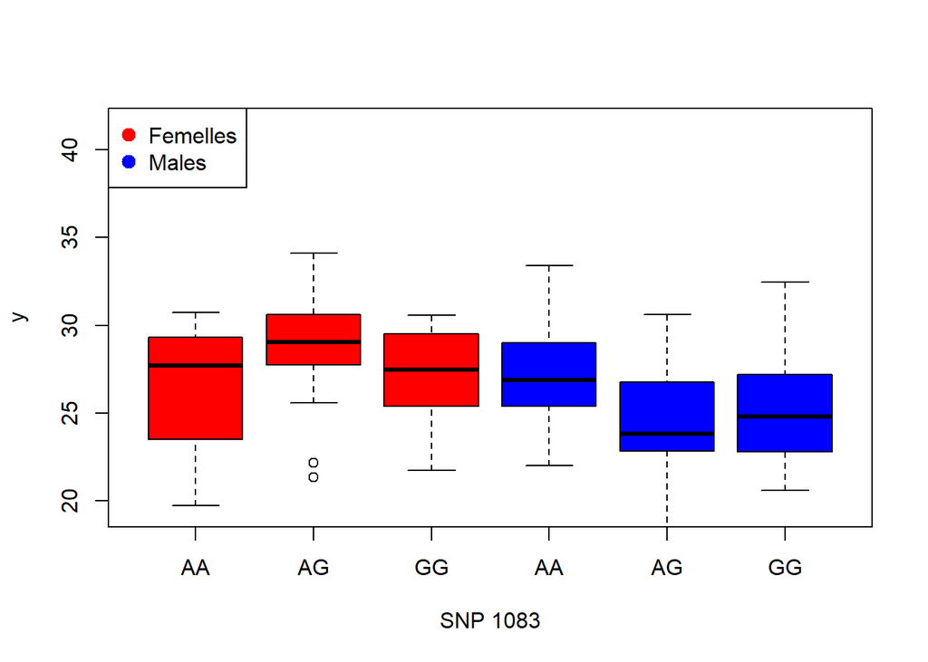

Comme précédemment, on a aucune interaction claire entre le sexe et les variables génétiques.

## C) Gènes Hsp * Gènes Pgi

Parmis les nouvelles variables ajoutées, certaines sont des gènes Hsp. Il est possible de trouver dans la littérature des interractions entre l’activation de ces gènes et celle des Hsp. On test dans le lien entre ces variables explicatives catégorielles.

#### — y ~ Pgi_105*Hsp

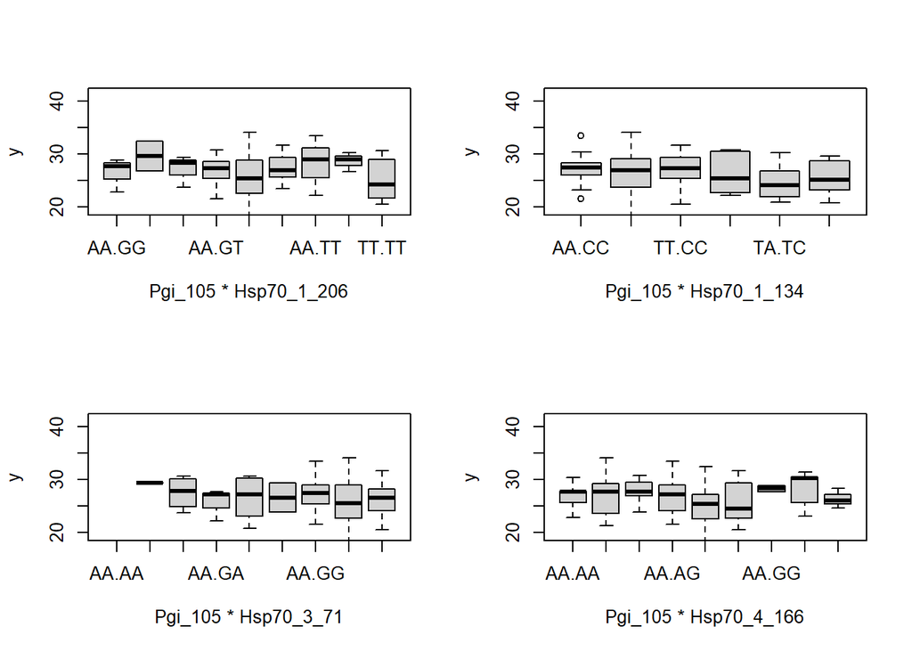

#### — y ~ Pgi_1083*Hsp

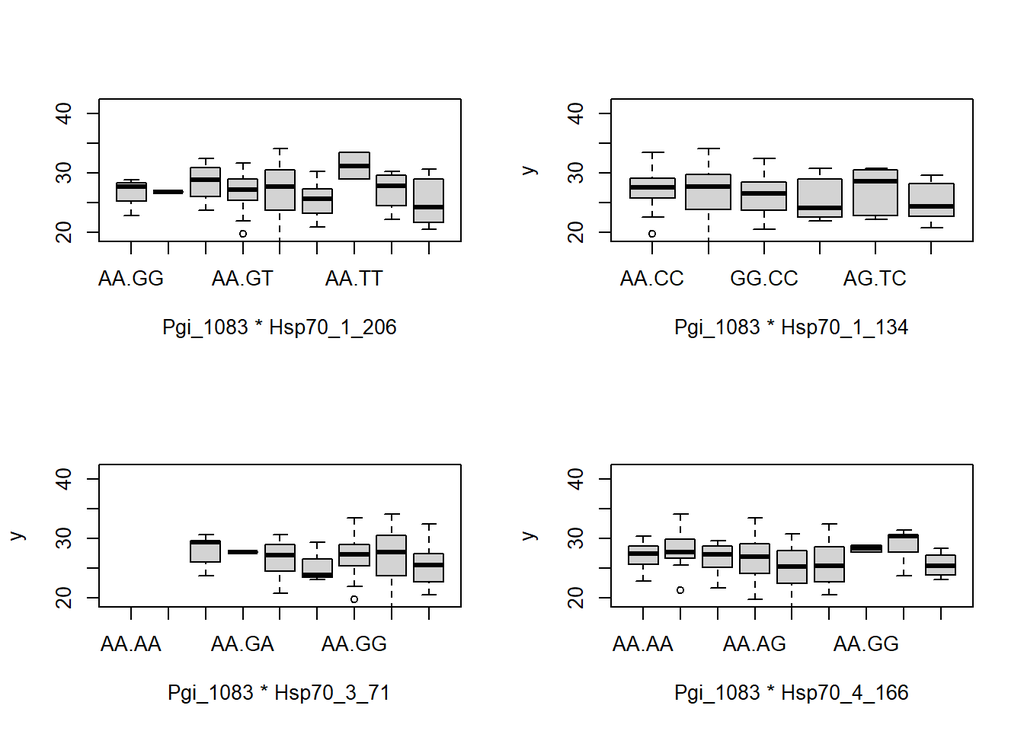

#### — y ~ Pgi_331*Hsp

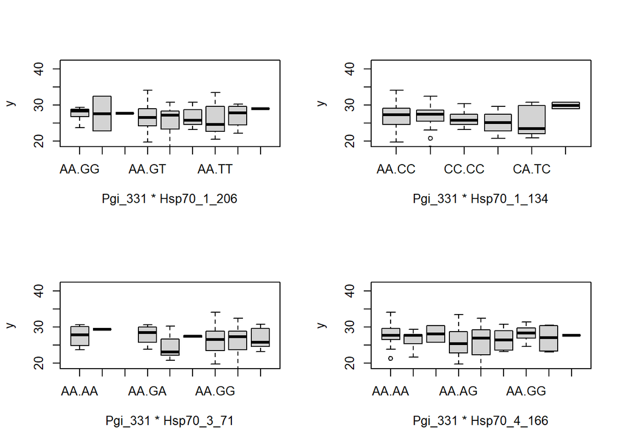

On observe aucune interraction entre les variables explicatives des gènes Hsp et des gènes Pgi.

# COLINEARITE ———————————————-

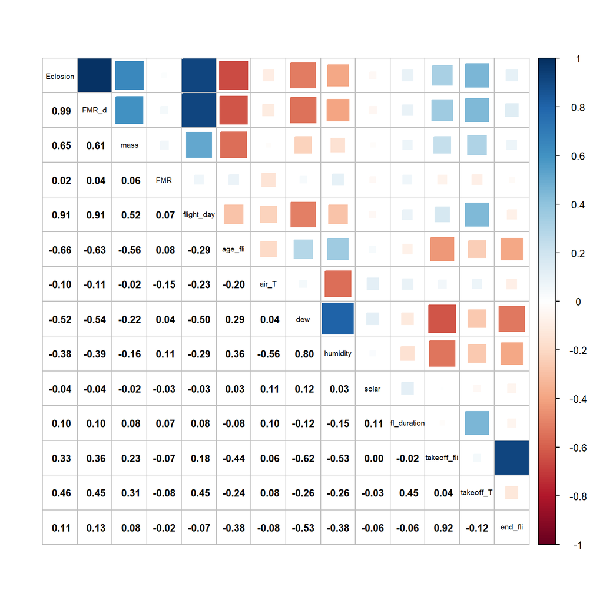

#### — Suppression des variables corrélées

```r
data <- data[!colnames(data) %in% c("eclosion_day", "dew_flight", "stop_flight", "end_flight_time", "flight_day", "age_flight")]

# On renomme le nom des lignes
rownames(data) <- 1:nrow(data)
```

# MODELISATION ———————————————-

### A. Sans effets aléatoires

Comme précédemment, on commence par le modèle “complet” en intégrant toutes les variables interprétables.

```r
mod <- lm(formula = mean_T_flight ~  FMR_day + age_FMR + FMR + sun_flight + air_T + humidity_flight + solar_radiation_flight + flight_duration + disturbed_flight + takeoff_T_thorax + (takeoff_time + mass + Pgi_105 + Pgi_1083 + Pgi_331)*sex + fln_113 + G6p1d_239 + Hsp70_4_166 + Hsp70_3_71 + Hsp70_1_134 + Hsp70_1_206 + SDHD_149 + TnT2_100,
          data = data)
```

#### — Multicolinéarité avec test VIF

On choisit un seuil entre >=5 pour le score VIF.

**Par itération**

```r
coli <- vif(mod, type = 'predictor')  # on supprime la variable wind_flight
coli[coli$GVIF == max(coli$GVIF),]["GVIF"]  # identification du plus grand vif
```

```
##         GVIF
## sex 30598.22
```

On supprime la variable ‘sex’

```
##                GVIF
## sun_flight 46.07616
```

On supprime la variable ‘sun_flight’

```
##                     GVIF
## humidity_flight 5.410344
```

On supprime la variable ‘humidity_flight’

```
##               GVIF
## G6p1d_239 5.173131
```

#### — Selection du meilleur modèle

On sélectionne le meilleur modèle avec une procédure backward / forward basée sur le critère de l’AIC.

```r
# On extrait la formule du modèle final
initial_formula <- formula(mod)

# Création modèle initial
initial_model <- lm(initial_formula, data = data)

# Utiliser step() pour sélectionner les termes du modèle
final_model <- step(initial_model, direction = "both", trace = FALSE, k = 3)

# Résultats
summary(final_model)
```

[output not shown]

```r
Anova(final_model, type = "III")
```

```
## Anova Table (Type III tests)
##
## Response: mean_T_flight
##                  Sum Sq Df  F value    Pr(>F)
## (Intercept)        7.38  1   2.2525 0.1371898
## air_T             98.86  1  30.1777 4.224e-07 ***
## flight_duration   51.63  1  15.7590 0.0001523 ***
## disturbed_flight  24.54  1   7.4903 0.0075865 **
## takeoff_T_thorax 436.33  1 133.1945 < 2.2e-16 ***
## Residuals        271.90 83
## ---
## Signif. codes:  0 '***' 0.001 '**' 0.01 '*' 0.05 '.' 0.1 ' ' 1
```

Tous les prédicteurs sont significatifs, c’est notre modèle candidat.  
NOTE : on utilise une ANOVA de type III car la distribution des effectifs des modalités de la variable catégorielle ‘disturbed_flight’ est inégale.

```r
mod_candidat <- final_model
```

Le **modèle candidat final** est donc le modèle ci-dessus. Avant de l’interpréter on évalue la qualité du modèle.

#### — Evaluations des résidus

**Normalité, homogénéité des variance et contributions aberrantes (Cooks)**

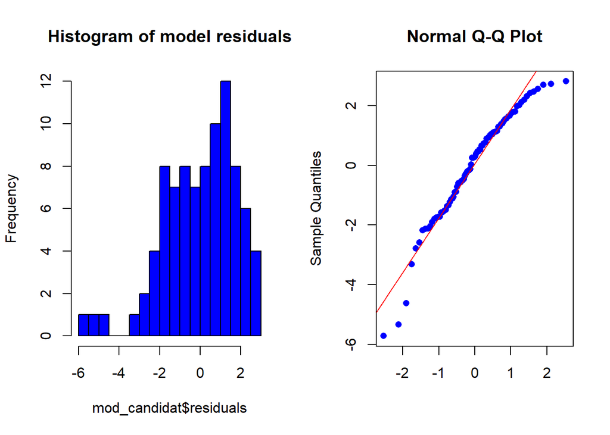

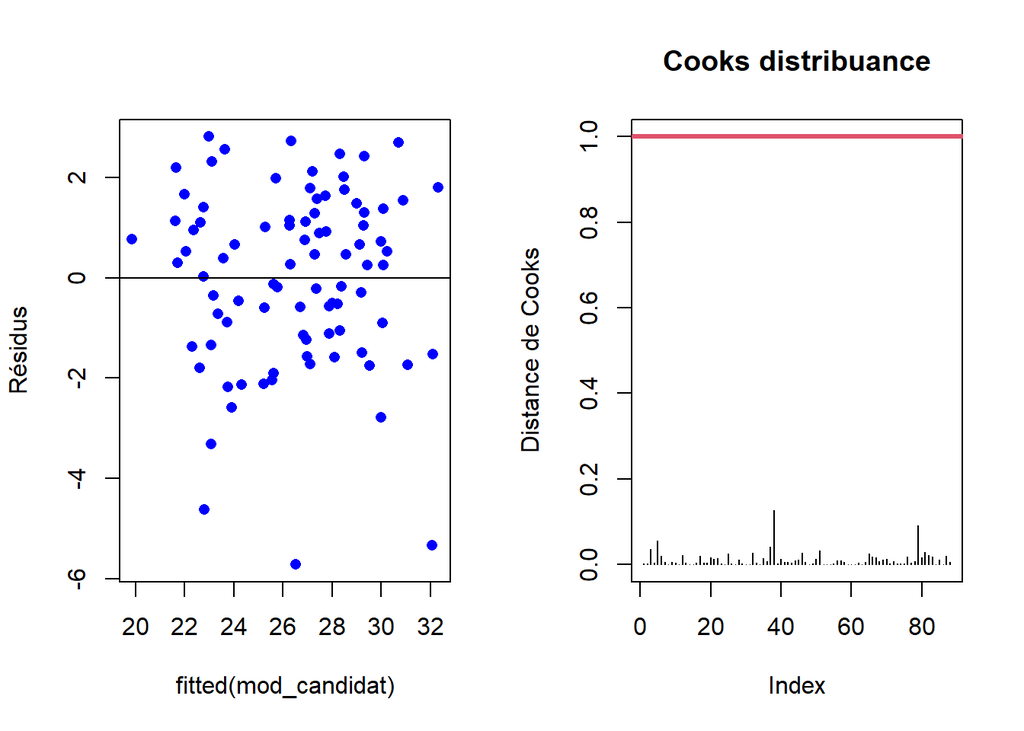

#### — Pouvoir explicatif de chaque variable prédictive

Pour rendre compte de la contribution de chaque variable, nous avons de nouveau calculé le ratio entre la contribution de chaque variable relativement à la variance totale :

```r
ano_mod <- Anova(mod_candidat, type = "III")
var_expliquee <- round(ano_mod$`Sum Sq`/ sum(ano_mod$`Sum Sq`), 3)  # Ratio de variance expliquée par variable
```

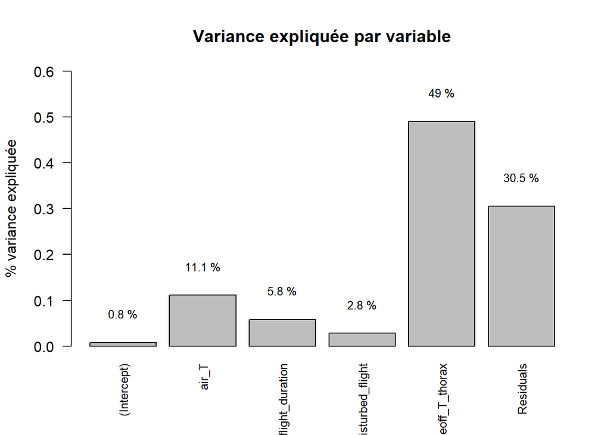

#### — Modèle final

**Le modèle est donc validé. La température moyenne du corps pendant le vol s’exprime par l’équation suivante :**

# CROSS VALIDATION DU MODELE (NA) ———————————————-

On cherche à valider le pouvoir prédictif du modèle candidat avec la méthode de la validation croisée en K-fold.

L’intérêt est de générer deux sous tableaux de données de tailles différentes : ‘Entraînement’ pour générer le modèle à partir ce ces données, et ‘Test’ afin de tester la précision du modèle. Ce processus est effectué K fois et à chaque fois, un score de précision est calculé. Le nombre K est choisi en fonction de la taille du dataset. Par défaut, on choisit K = 10.

Le résultat est une valeur de précision du modèle retenu (R²), les coefficients de chaque variable et l’erreur associée (RMSE et MAE).

La cross validation est possible grâce aux fonction ‘trainControl’ et ‘train’ du package ‘caret’.

```r
set.seed(100)
k <- 10 # Valeur par defaut souvent utilisee

# Définir le contrôle de la validation croisée avec preProcess
ctrl <- trainControl(method = "cv", number = k)
# Method = cross validation
# number = nombre de plis
# Mettre l'argument "MedianImpute" permet de combler les NAs

# Entraîner le modèle avec train()
model <- train(mean_T_flight ~ air_T + flight_duration + disturbed_flight + takeoff_T_thorax, data = data,
               method = "glm", trControl = ctrl, na.action = na.omit)

# Les NAs sont omis pour avoir le meme modele qu'initialement
# Cependant, il est possible d'utiliser l'argument 'MedianImpute' dans la fonction trainControl pour générer des valeurs pour les NAs

print(model)
```

```
## Generalized Linear Model
##
## 88 samples
##  4 predictor
##
## No pre-processing
## Resampling: Cross-Validated (10 fold)
## Summary of sample sizes: 80, 79, 78, 80, 78, 79, ...
## Resampling results:
##
##   RMSE      Rsquared   MAE
##   1.777647  0.7512194  1.500266
```

Les paramètres pour chaque pli :

```r
model$resample
```

```
##         RMSE  Rsquared       MAE Resample
## 1  1.9150248 0.6891363 1.7767444   Fold01
## 2  2.3921470 0.8148310 1.9679028   Fold02
## 3  1.3181430 0.8221348 1.1152701   Fold03
## 4  2.6644542 0.3863904 2.0799121   Fold04
## 5  1.3617498 0.8933727 1.1251384   Fold05
## 6  0.9754348 0.8521018 0.8046328   Fold06
## 7  1.6181121 0.8241868 1.3890999   Fold07
## 8  2.5580402 0.6059522 2.1048149   Fold08
## 9  1.5416110 0.7587253 1.3136202   Fold09
## 10 1.4317558 0.8653629 1.3255281   Fold10
```

```r
paste0("R2_mean = ", round(model$results$Rsquared, 3) , " +/- ", round(model$results$RsquaredSD, 3))
```

```
## [1] "R2_mean = 0.751 +/- 0.155"
```

# Conclusion

Les différentes approches de modélisation ont donné des résultats similaires que ce soit (1) avec la méthode de validation croisée et/ou (2) l’imputation des données manquantes. On retrouve globablement le même modèle. L’imputation des données manquantes a permis de confirmer l’absence de contribution des variables génétiques, qui n’ont pas été retrouvé dans le modèle final pour expliquer la température au vol du papillon. La méthode de validation croisée a permis de confirmer que le pouvoir prédictif du modèle initital était stable (cf R2).